# Andropogoneae Species

Michelle C. Stitzer

# *Zea diploperennis Gigi*

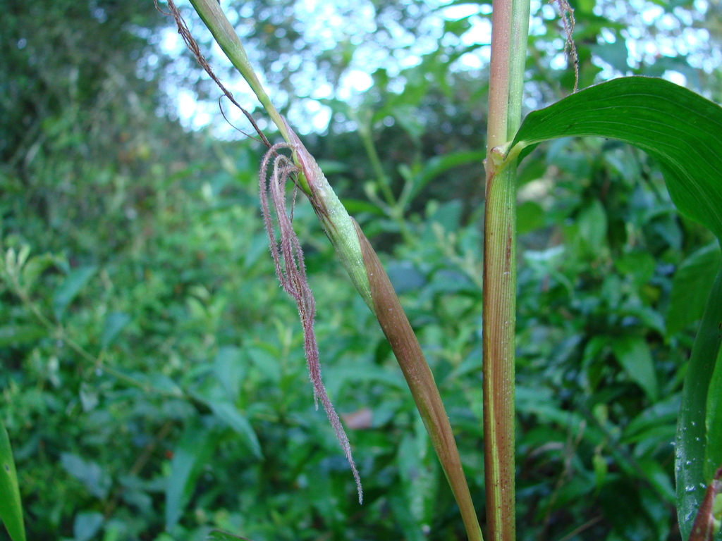

[Photo by Jaime Marcelo Aranda Sanchez, licensed under CC-BY-NC 4.0](https://www.inaturalist.org/photos/13375176)

#### The assembly is haploid, and the genome is paleotetraploid. It has a haploid genome size of 3300 Mb, and has 10 haploid chromosomes.

### Species herbarium records

Herbarium records of *Zea diploperennis Gigi* from [AuBuchon-Elder et al 2022](https://nph.onlinelibrary.wiley.com/doi/full/10.1002/ppp3.10355) are plotted with black points, The sampled individual this genome was generated from is shown in a colored point. The green background shows the biogeographic ranges of all Andropogoneae species in [AuBuchon-Elder et al 2022](https://nph.onlinelibrary.wiley.com/doi/full/10.1002/ppp3.10355).

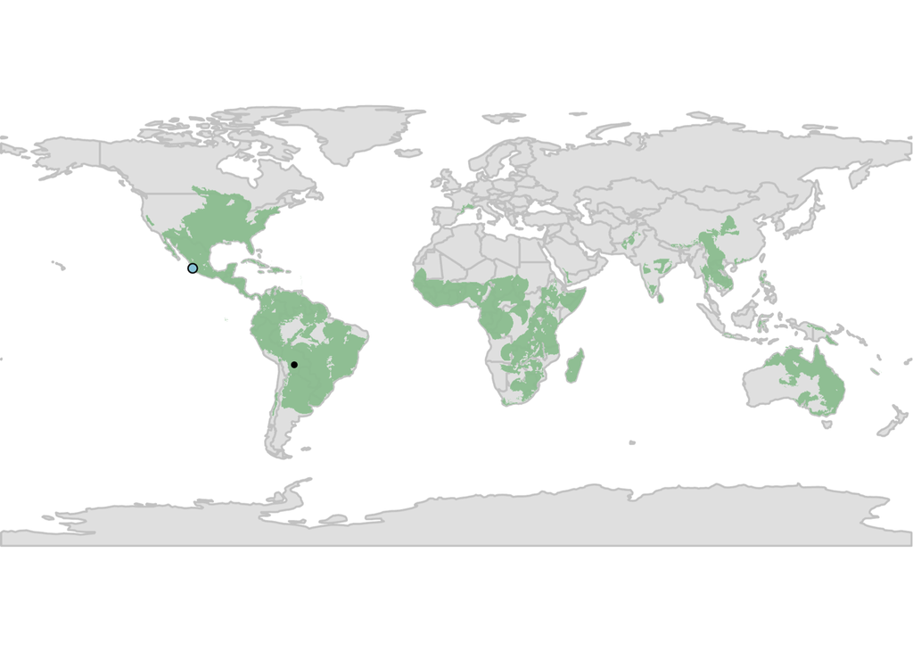

### Highlighted Figure 1

Figure 1 from the main text, with *Zea diploperennis Gigi* highlighted with colored points.

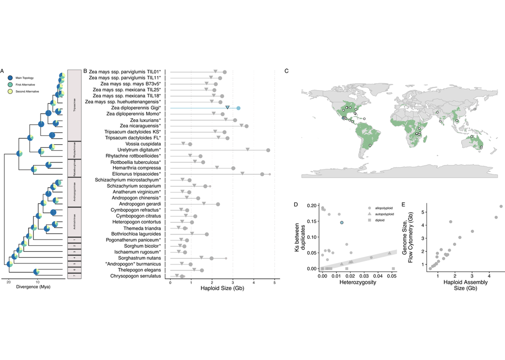

### Highlighted Figure 2

Figure 2 from the main text, with *Zea diploperennis Gigi* highlighted with colored points.

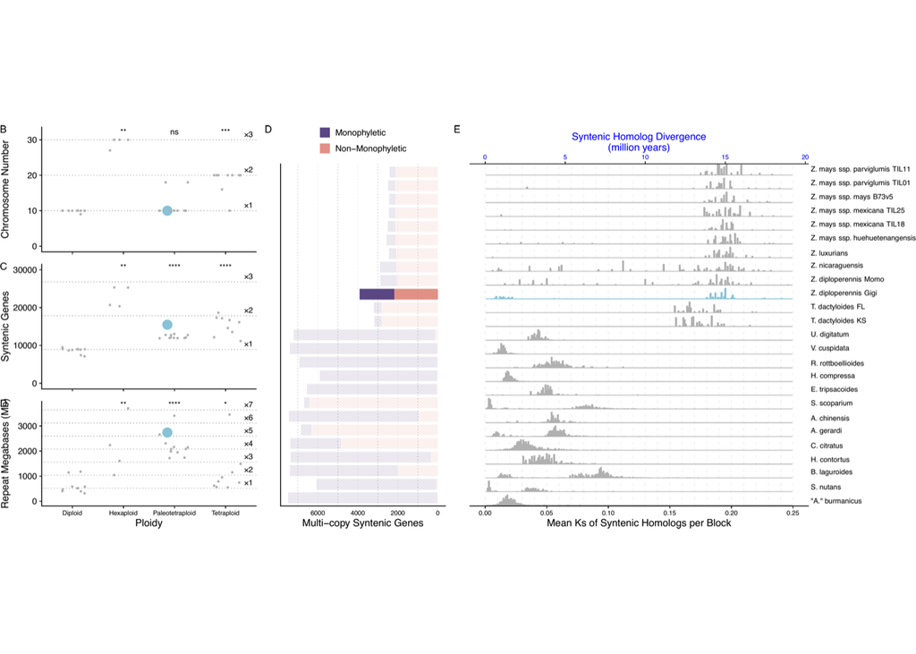

### Dotplot of *Zea diploperennis Gigi* vs. *Paspalum vaginatum*

Like dotplots shown in Figure 3 of the main text, this shows syntenic blocks in *Zea diploperennis Gigi* along the y-axis, vs *P. vaginatum* on the x-axis. As Zea diploperennis Gigi is a paleotetraploid with a haploid assembly, we expect 2 paths for any x-axis position.

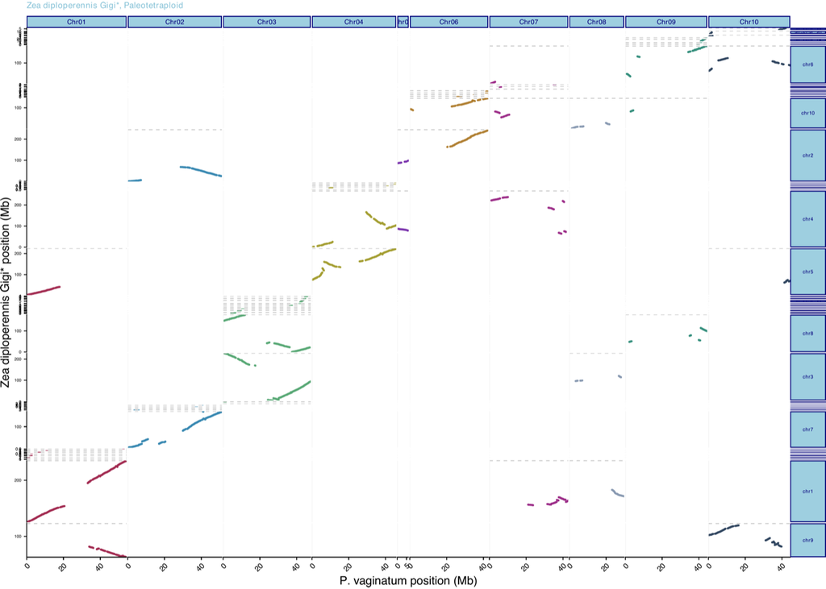

### Fractionation of *Zea diploperennis Gigi*

Like plots shown in Figure 4 of the main text, this shows proportion of retained genes in Zea diploperennis Gigi along the y-axis, vs P. vaginatum gene index on the x-axis. As *Zea diploperennis Gigi* is a paleotetraploid with a haploid assembly, we expect 2 lines, one for each subgenome.

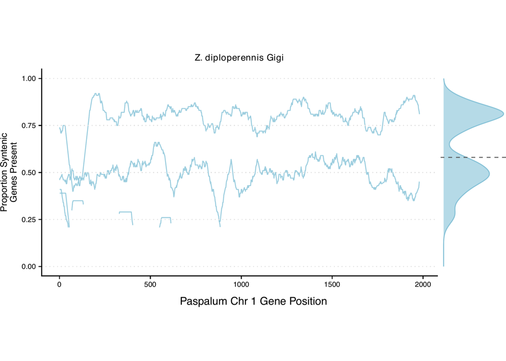

### Highlighted Figure 5

Figure 5 from the main text, with *Zea diploperennis Gigi* highlighted with colored points or lines.

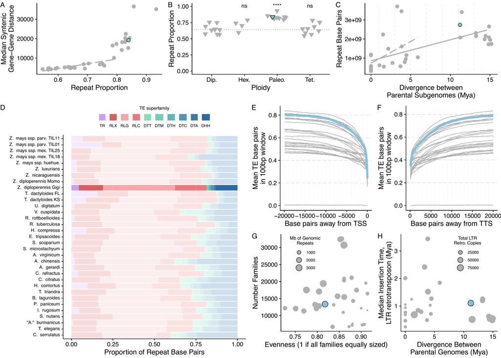

### Spatial distribution of genes and TEs

Density of genes and repeats along the longest sequence (contig, scaffold, or chromosome) of *Zea diploperennis Gigi* in 1 Mb bins. Gene annotation shown is all Helixer genes.

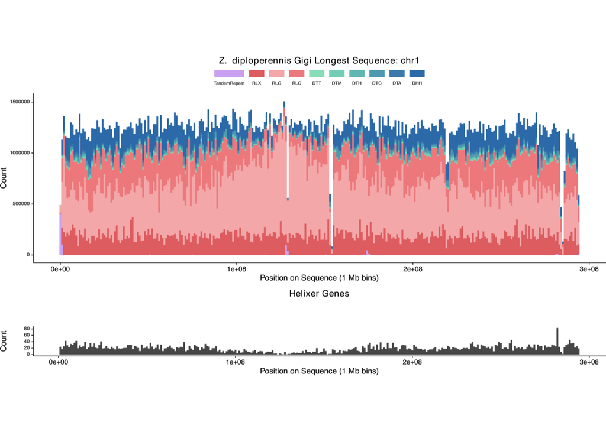